# Compare CVs between individuals, remove PCs

Joyce Hsiao

2015-10-26

**Last updated:** 2015-10-26

**Code version:** 7aa2149f5303671c42051c2875aaebf5db5ad089

**Last updated:** 2015-10-27

**Code version:** f4be18c104f70809fbbd1acf23293745e7a0e69d

## Objective

We filted the first PC from the data and computed per gene CVs based on the filtered data. We observed that the adjusted CV profiles differed significantly between the three individuals.

## Set up

```r
library("data.table")
library("dplyr")
library("limma")
library("edgeR")
library("ggplot2")
library("grid")
theme_set(theme_bw(base_size = 12))
source("functions.R")
```

## Prepare data

Input annotation of only QC-filtered single cells. Remove NA19098.r2

```r
anno_qc <- read.table("../data/annotation-filter.txt", header = TRUE,
                   stringsAsFactors = FALSE)
is_include <- anno_qc$batch != "NA19098.r2"
anno_qc_filter <- anno_qc[which(is_include), ]
```

Import endogeneous gene molecule counts that are QC-filtered, CPM-normalized, ERCC-normalized, and also processed to remove unwanted variation from batch effet. ERCC genes are removed from this file.

```r
molecules_ENSG <- read.table("../data/molecules-final.txt", header = TRUE, stringsAsFactors = FALSE)
molecules_ENSG <- molecules_ENSG[ , is_include]
```

Input moleclule counts before log2 CPM transformation. This file is used to compute percent zero-count cells per sample.

```r
molecules_sparse <- read.table("../data/molecules-filter.txt", header = TRUE, stringsAsFactors = FALSE)

molecules_sparse <- molecules_sparse[grep("ENSG", rownames(molecules_sparse)), ]
stopifnot( all.equal(rownames(molecules_ENSG), rownames(molecules_sparse)) )
```

## SVD/PCA

```r
library(matrixStats)
centered_ENSG <- molecules_ENSG - rowMeans(molecules_ENSG)
svd_all <- svd( centered_ENSG )
head( (svd_all$d^2)/(sum(svd_all$d^2) ) )
```

```
[1] 0.285443497 0.015628715 0.007801029 0.004410760 0.002839127 0.002824898
```

```r
# reproduce SVD results with PCA
# pca_results <- prcomp( t(centered_ENSG) )
# head((pca_results$sdev^2)/(sum(pca_results$sdev^2)) )

par(mfrow = c(2,2))
plot(x = rowMeans(molecules_ENSG), y = svd_all$u[ ,1],
     xlab = "mean molecule counts", ylab = "first eigen-cell", cex = .4)
plot(x = rowMeans(molecules_ENSG), y = svd_all$u[ ,2],
     xlab = "mean molecule counts", ylab = "second eigen-cell", cex = .4)
plot(x = rowMeans(molecules_ENSG), y = svd_all$u[ ,3],
     xlab = "mean molecule counts", ylab = "third eigen-cell", cex = .4)
plot(x = rowMeans(molecules_ENSG), y = svd_all$u[ ,4],
     xlab = "mean molecule counts", ylab = "third eigen-cell", cex = .4)
```

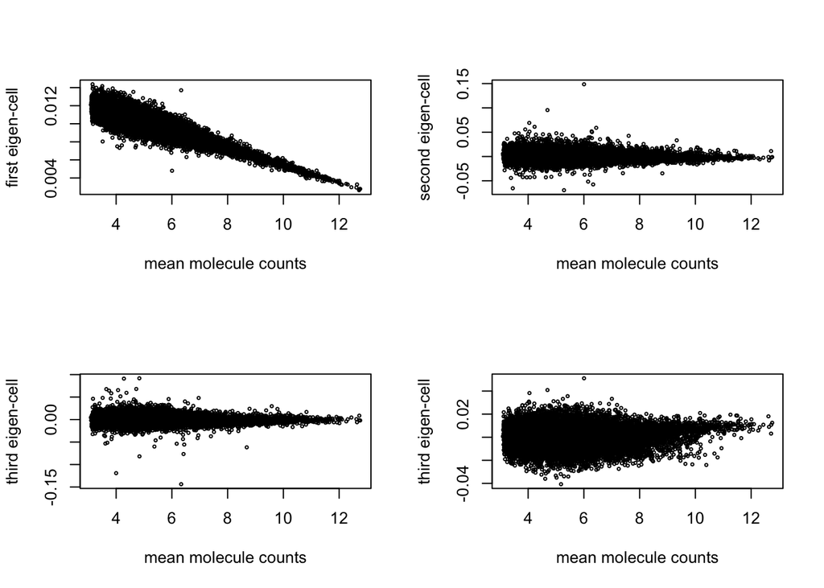

[figure not shown]

```r
cor(rowMeans(molecules_ENSG), y = svd_all$u[ ,1], method ="spearman")
```

```
[1] -0.8978574
```

1. First PC ~ mean gene expression levels/percent genes detected
2. Second PC ?
3. Third PC ~ differences between the three individuals…

```r
library(gridExtra)
p1 <- ggplot(data.frame(pc1 = svd_all$v[,1],
                        pc2 = svd_all$v[,2],
                        individual = anno_qc_filter$individual),
              aes(x = pc1, y = pc2, col = individual)) +
        geom_point()

p2 <- ggplot(data.frame(pc2 = svd_all$v[,2],
                        pc3 = svd_all$v[,3],
                        individual = anno_qc_filter$individual),
            aes(x = pc3, y = pc2, col = individual) ) +
        geom_point()

grid.arrange(p1, p2, ncol = 2)
```

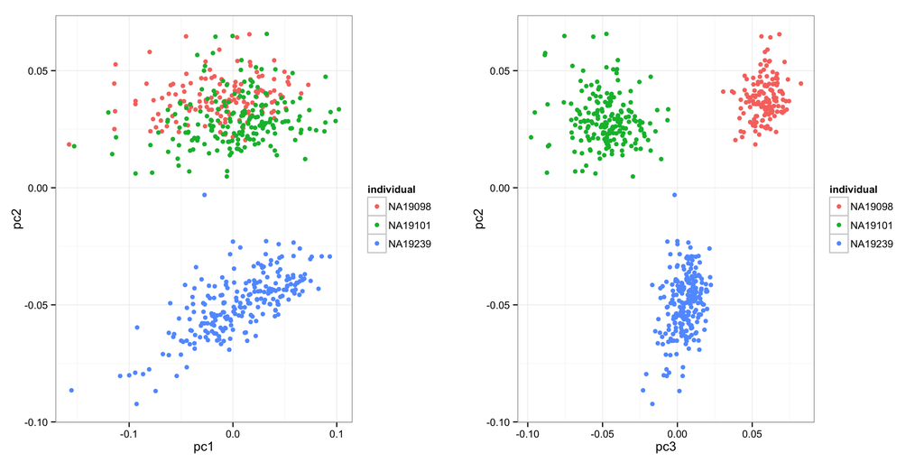

[figure not shown]

## Remove the first PC

```r
filtered_data <- with(svd_all, u %*% diag( c(0, d[-1]) ) %*% t(v))
```

## Compute CV of the filtered data

```r
cv_filtered <- lapply(1:3, function(ii_individual) {
    individuals <- unique(anno_qc_filter$individual)
    counts <- filtered_data[ , anno_qc_filter$individual == individuals [ii_individual]]
    means <- apply(counts, 1, mean)
    sds <- apply(counts, 1, sd)
    cv <- sds/means
    return(cv)
})
names(cv_filtered) <- unique(anno_qc_filter$individual)
cv_filtered <- do.call(cbind, cv_filtered)
rownames(cv_filtered) <- rownames(molecules_ENSG)
friedman.test(cv_filtered)
```

```
    Friedman rank sum test

data:  cv_filtered
Friedman chi-squared = 38.306, df = 2, p-value = 4.808e-09
```

```r
friedman.test(cv_filtered[ , c(1,2)])
```

```
    Friedman rank sum test

data:  cv_filtered[, c(1, 2)]
Friedman chi-squared = 3.931, df = 1, p-value = 0.0474
```

```r
friedman.test(cv_filtered[ , c(1,3)])
```

```
    Friedman rank sum test

data:  cv_filtered[, c(1, 3)]
Friedman chi-squared = 40.926, df = 1, p-value = 1.581e-10
```

```r
friedman.test(cv_filtered[ , c(2,3)])
```

```
    Friedman rank sum test

data:  cv_filtered[, c(2, 3)]
Friedman chi-squared = 7.2141, df = 1, p-value = 0.007233
```

## Cell-cycle genes

Import cell-cycle genes.

```r
cellcycle_genes <- read.table("../data/cellcyclegenes.txt", sep = "\t",
                              header = TRUE)
dim(cellcycle_genes)
```

```
[1] 151   5
```

```r
ii_cellcycle <- rownames(cv_filtered) %in% unlist(cellcycle_genes)
friedman.test(cv_filtered[which(ii_cellcycle), ])
```

```
    Friedman rank sum test

data:  cv_filtered[which(ii_cellcycle), ]
Friedman chi-squared = 16.37, df = 2, p-value = 0.0002789
```

Non-cell-cycle genes

```r
friedman.test(cv_filtered[which(!ii_cellcycle), ] )
```

```
    Friedman rank sum test

data:  cv_filtered[which(!ii_cellcycle), ]
Friedman chi-squared = 29.395, df = 2, p-value = 4.139e-07
```

## Pluripotent genes

```r
pluripotent_genes <- read.table("../data/pluripotency-genes.txt", sep = "\t",
                                header = TRUE)$To
```

Friedman test.

```r
ii_pluripotent <- (rownames(cv_filtered) %in% unlist(pluripotent_genes))
pca_all_pluripotent <- cv_filtered[which(ii_pluripotent), ]
friedman.test(pca_all_pluripotent)
```

```
    Friedman rank sum test

data:  pca_all_pluripotent
Friedman chi-squared = 3, df = 2, p-value = 0.2231
```

## Find driving genes of PC2

```r
# compute data-wide cv
data_cv <- apply(molecules_ENSG, 1, sd)/apply(molecules_ENSG, 1, mean)
par(mfrow = c(2,2))
plot(x = data_cv, y = svd_all$u[ ,1])
plot(x = data_cv, y = svd_all$u[ ,2])
plot(x = data_cv, y = svd_all$u[ ,3])
plot(x = data_cv, y = svd_all$u[ ,4])
```

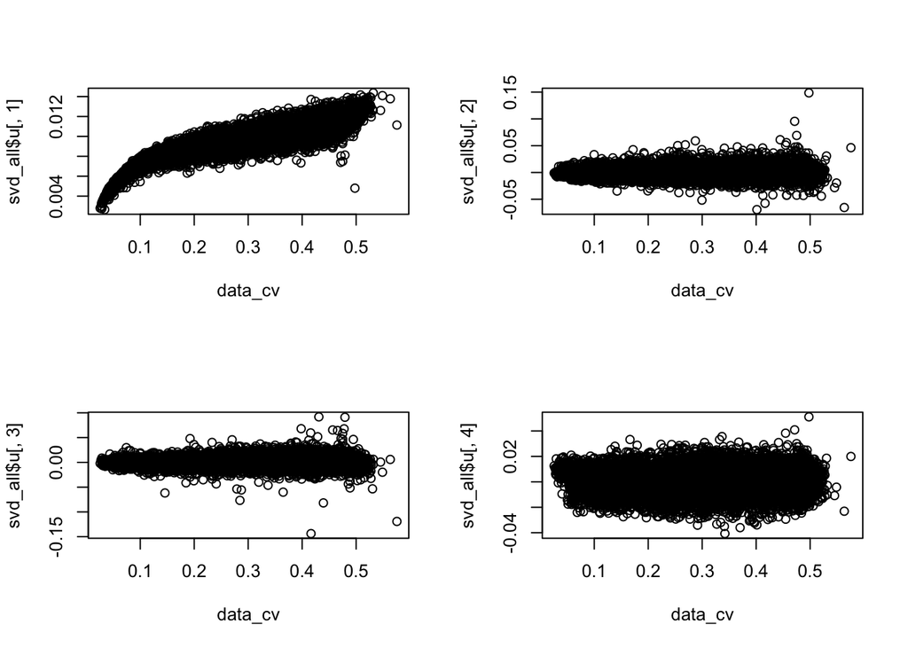

[figure not shown]

```r
# compute data-wide cv based on the filtered data
filtered_data_cv <- apply(filtered_data, 1, sd)/apply(filtered_data, 1, mean)
par(mfrow = c(2,2))
plot(x = filtered_data_cv, y = svd_all$u[ ,1])
plot(x = filtered_data_cv, y = svd_all$u[ ,2])
plot(x = filtered_data_cv, y = svd_all$u[ ,3])
plot(x = filtered_data_cv, y = svd_all$u[ ,4])
```

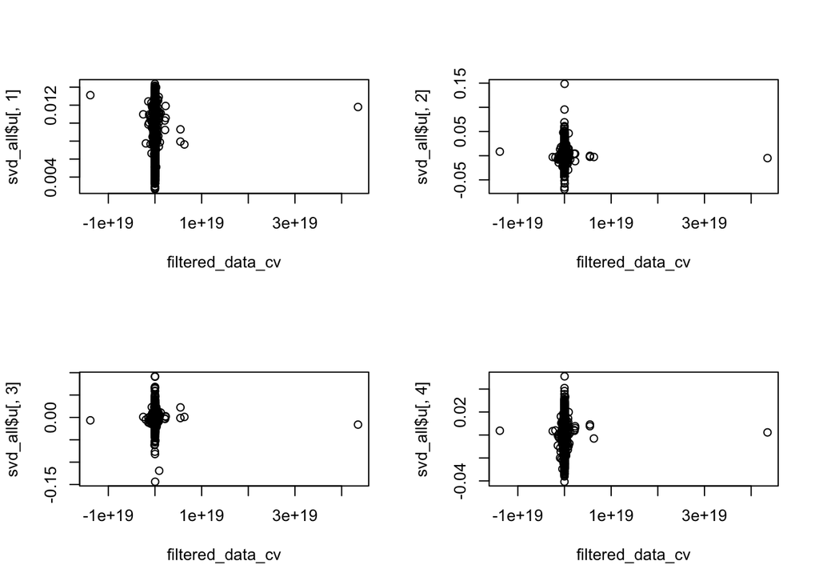

[figure not shown]

```r
pc2_genes <- svd_all$u[,2]

# find genes outside of 3 mean +/- sd
mean_pc2 <- mean(pc2_genes)
sd_pc2 <- sd(pc2_genes)
ii_extreme <- which( (pc2_genes > mean_pc2 + 3*sd_pc2)|(pc2_genes < mean_pc2 - 3*sd_pc2) )
length(ii_extreme)
```

```
[1] 110
```

```r
library(broman)
par(mfrow = c(1,1))
xy <- cbind(c(1:length(pc2_genes)), pc2_genes)
plot(xy, cex = .4, pch = 16,
     main = paste("PC2 gene loadings \n",
                  length(ii_extreme), "genes"), xlab = "genes", ylab = "PC2 loadings")
points(xy[ii_extreme, ], pch = 1, cex = .7, col = brocolors("crayon")["Red Orange"])
```

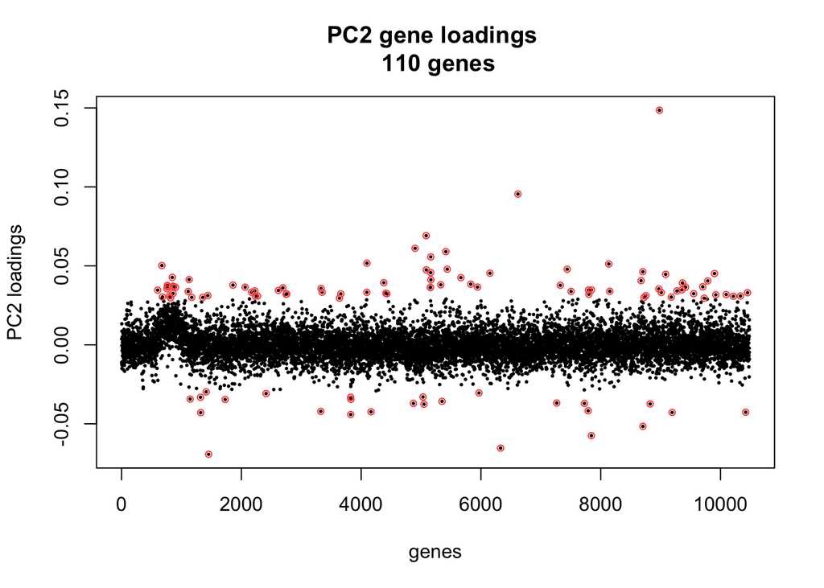

[figure not shown]

Annotation

```r
library("biomaRt")
ensembl <- useMart(host = "grch37.ensembl.org",
                   biomart = "ENSEMBL_MART_ENSEMBL",
                   dataset = "hsapiens_gene_ensembl")
pc2_gene_info <- getBM(attributes = c("ensembl_gene_id", "chromosome_name",
                                       "external_gene_name", "transcript_count",
                                       "description"),
                        filters = "ensembl_gene_id",
                        values = rownames(molecules_ENSG[ii_extreme, ]),
                        mart = ensembl)
kable(pc2_gene_info[ , c(1, 2, 3, 5)])
```

| ensembl_gene_id | chromosome_name | external_gene_name | description |
| --- | --- | --- | --- |
| ENSG00000007080 | 19 | CCDC124 | coiled-coil domain containing 124 [Source:HGNC Symbol;Acc:25171] |
| ENSG00000022556 | 19 | NLRP2 | NLR family, pyrin domain containing 2 [Source:HGNC Symbol;Acc:22948] |
| ENSG00000026025 | 10 | VIM | vimentin [Source:HGNC Symbol;Acc:12692] |
| ENSG00000048392 | 8 | RRM2B | ribonucleotide reductase M2 B (TP53 inducible) [Source:HGNC Symbol;Acc:17296] |
| ENSG00000048540 | 12 | LMO3 | LIM domain only 3 (rhombotin-like 2) [Source:HGNC Symbol;Acc:6643] |
| ENSG00000053438 | 20 | NNAT | neuronatin [Source:HGNC Symbol;Acc:7860] |
| ENSG00000064042 | 4 | LIMCH1 | LIM and calponin homology domains 1 [Source:HGNC Symbol;Acc:29191] |
| ENSG00000066084 | 12 | DIP2B | DIP2 disco-interacting protein 2 homolog B (Drosophila) [Source:HGNC Symbol;Acc:29284] |
| ENSG00000075391 | 1 | RASAL2 | RAS protein activator like 2 [Source:HGNC Symbol;Acc:9874] |
| ENSG00000076924 | 19 | XAB2 | XPA binding protein 2 [Source:HGNC Symbol;Acc:14089] |
| ENSG00000078295 | 5 | ADCY2 | adenylate cyclase 2 (brain) [Source:HGNC Symbol;Acc:233] |
| ENSG00000085552 | 1 | IGSF9 | immunoglobulin superfamily, member 9 [Source:HGNC Symbol;Acc:18132] |
| ENSG00000095739 | 10 | BAMBI | BMP and activin membrane-bound inhibitor [Source:HGNC Symbol;Acc:30251] |
| ENSG00000101850 | X | GPR143 | G protein-coupled receptor 143 [Source:HGNC Symbol;Acc:20145] |
| ENSG00000104722 | 8 | NEFM | neurofilament, medium polypeptide [Source:HGNC Symbol;Acc:7734] |
| ENSG00000105669 | 19 | COPE | coatomer protein complex, subunit epsilon [Source:HGNC Symbol;Acc:2234] |
| ENSG00000106078 | 7 | COBL | cordon-bleu WH2 repeat protein [Source:HGNC Symbol;Acc:22199] |
| ENSG00000106153 | 7 | CHCHD2 | coiled-coil-helix-coiled-coil-helix domain containing 2 [Source:HGNC Symbol;Acc:21645] |
| ENSG00000106236 | 7 | NPTX2 | neuronal pentraxin II [Source:HGNC Symbol;Acc:7953] |
| ENSG00000107105 | 9 | ELAVL2 | ELAV like neuron-specific RNA binding protein 2 [Source:HGNC Symbol;Acc:3313] |
| ENSG00000108821 | 17 | COL1A1 | collagen, type I, alpha 1 [Source:HGNC Symbol;Acc:2197] |
| ENSG00000110092 | 11 | CCND1 | cyclin D1 [Source:HGNC Symbol;Acc:1582] |
| ENSG00000112394 | 6 | SLC16A10 | solute carrier family 16 (aromatic amino acid transporter), member 10 [Source:HGNC Symbol;Acc:17027] |
| ENSG00000115339 | 2 | GALNT3 | UDP-N-acetyl-alpha-D-galactosamine:polypeptide N-acetylgalactosaminyltransferase 3 (GalNAc-T3) [Source:HGNC Symbol;Acc:4125] |
| ENSG00000120889 | 8 | TNFRSF10B | tumor necrosis factor receptor superfamily, member 10b [Source:HGNC Symbol;Acc:11905] |
| ENSG00000121101 | 17 | TEX14 | testis expressed 14 [Source:HGNC Symbol;Acc:11737] |
| ENSG00000123243 | 10 | ITIH5 | inter-alpha-trypsin inhibitor heavy chain family, member 5 [Source:HGNC Symbol;Acc:21449] |
| ENSG00000123560 | X | PLP1 | proteolipid protein 1 [Source:HGNC Symbol;Acc:9086] |
| ENSG00000124313 | X | IQSEC2 | IQ motif and Sec7 domain 2 [Source:HGNC Symbol;Acc:29059] |
| ENSG00000124839 | 2 | RAB17 | RAB17, member RAS oncogene family [Source:HGNC Symbol;Acc:16523] |

[output cut: 80 more lines]

```r
if (file.exists("rda/svd-filtered/pc2-cv.rda")) {
  load("rda/svd-filtered/pc2-cv.rda")
} else {
  library(Humanzee)
  go_pc2 <- GOtest(my_ensembl_gene_universe = rownames(molecules_ENSG),
                my_ensembl_gene_test = rownames(molecules_ENSG)[ii_extreme],
                pval_cutoff = 1, ontology=c("BP","CC","MF") )
  save(go_pc2, file = "rda/svd-filtered/pc2-cv.rda")
}
```

Extract terms

```r
if (file.exists("rda/svd-filtered/go-pc2-terms.rda")) {
  load("rda/svd-filtered/go-pc2-terms.rda")
} else {
  # Biological process
  goterms_bp <- summary(go_pc2$GO$BP, pvalue = 1)
  goterms_bp <- data.frame(ID = goterms_bp[[1]],
                           Pvalue = goterms_bp[[2]],
                           Terms = goterms_bp[[7]])
  goterms_bp <- goterms_bp[order(goterms_bp$Pvalue), ]

  # Cellular component
  goterms_cc <- summary(go_pc2$GO$CC, pvalue = 1)
  goterms_cc <- data.frame(ID = goterms_cc[[1]],
                           Pvalue = goterms_cc[[2]],
                           Terms = goterms_cc[[7]])
  goterms_cc <- goterms_cc[order(goterms_cc$Pvalue), ]

  # Molecular function
  goterms_mf <- summary(go_pc2$GO$MF, pvalue = 1)
  goterms_mf <- data.frame(ID = goterms_mf[[1]],
                           Pvalue = goterms_mf[[2]],
                           Terms = goterms_mf[[7]])
  goterms_mf <- goterms_mf[order(goterms_mf$Pvalue), ]

  save(goterms_bp, goterms_cc, goterms_mf,
       file = "rda/svd-filtered/go-pc2-terms.rda")
}
```

```r
head(goterms_bp, 20)
```

```
           ID       Pvalue
1  GO:0010043 4.233878e-05
2  GO:0071294 6.411339e-05
3  GO:1902305 1.795128e-04
4  GO:1990267 2.651255e-04
5  GO:0048669 3.380583e-04
6  GO:1903273 3.380583e-04
7  GO:1903275 3.380583e-04
8  GO:1903276 3.380583e-04
9  GO:1903278 3.380583e-04
10 GO:1903286 3.380583e-04
11 GO:1903288 3.380583e-04
12 GO:0045926 3.525005e-04
13 GO:0050794 3.846393e-04
14 GO:0050789 4.175013e-04
```

[output cut: 27 more lines]

```r
head(goterms_cc, 20)
```

```
           ID      Pvalue                                            Terms
1  GO:0005886 0.001486595                                  plasma membrane
2  GO:0005890 0.001518698       sodium:potassium-exchanging ATPase complex
3  GO:0016323 0.002148167                      basolateral plasma membrane
4  GO:0071944 0.002224033                                   cell periphery
5  GO:0044459 0.003264812                             plasma membrane part
6  GO:0090533 0.003572430               cation-transporting ATPase complex
7  GO:0031226 0.003674196           intrinsic component of plasma membrane
8  GO:0016324 0.004219984                           apical plasma membrane
9  GO:0045177 0.005759799                              apical part of cell
10 GO:0098533 0.007536376 ATPase dependent transmembrane transport complex
11 GO:0005887 0.007724379            integral component of plasma membrane
12 GO:0098590 0.008426372                           plasma membrane region
13 GO:0032591 0.010249974                         dendritic spine membrane
14 GO:0036477 0.017893454                      somatodendritic compartment
15 GO:0005584 0.020395947                           collagen type I trimer
16 GO:0005967 0.020395947     mitochondrial pyruvate dehydrogenase complex
17 GO:0008043 0.020395947                   intracellular ferritin complex
18 GO:0033162 0.020395947                              melanosome membrane
19 GO:0045009 0.020395947                                        chitosome
20 GO:0045025 0.020395947                        mitochondrial degradosome
```

```r
head(goterms_mf, 20)
```

```
           ID       Pvalue
1  GO:0004551 0.0006593199
2  GO:0005391 0.0016255779
3  GO:0008556 0.0016255779
4  GO:0001671 0.0068617248
5  GO:0035035 0.0080535610
6  GO:0004081 0.0106095053
7  GO:0004654 0.0106095053
8  GO:0005275 0.0106095053
9  GO:0008504 0.0106095053
10 GO:0008796 0.0106095053
11 GO:0008803 0.0106095053
12 GO:0015222 0.0106095053
13 GO:0035240 0.0106095053
14 GO:0035643 0.0106095053
```

[output cut: 36 more lines]

## Find driving genes of PC3

```r
pc3_genes <- svd_all$u[ ,3]

# find genes outside of 3 mean +/- sd
mean_pc3 <- mean(pc3_genes)
sd_pc3 <- sd(pc3_genes)
ii_extreme <- which( (pc3_genes > mean_pc2 + 3*sd_pc2)|(pc3_genes < mean_pc2 - 3*sd_pc2) )
length(ii_extreme)
```

```
[1] 94
```

```r
library(broman)
par(mfrow = c(1,1))
xy <- cbind(c(1:length(pc3_genes)), pc3_genes)
plot(xy, cex = .4, pch = 16,
     main = paste("PC3 gene loadings \n",
                  length(ii_extreme), "genes"), xlab = "genes", ylab = "PC3 loadings")
points(xy[ii_extreme, ], pch = 1, cex = .7, col = brocolors("crayon")["Shamrock"])
```

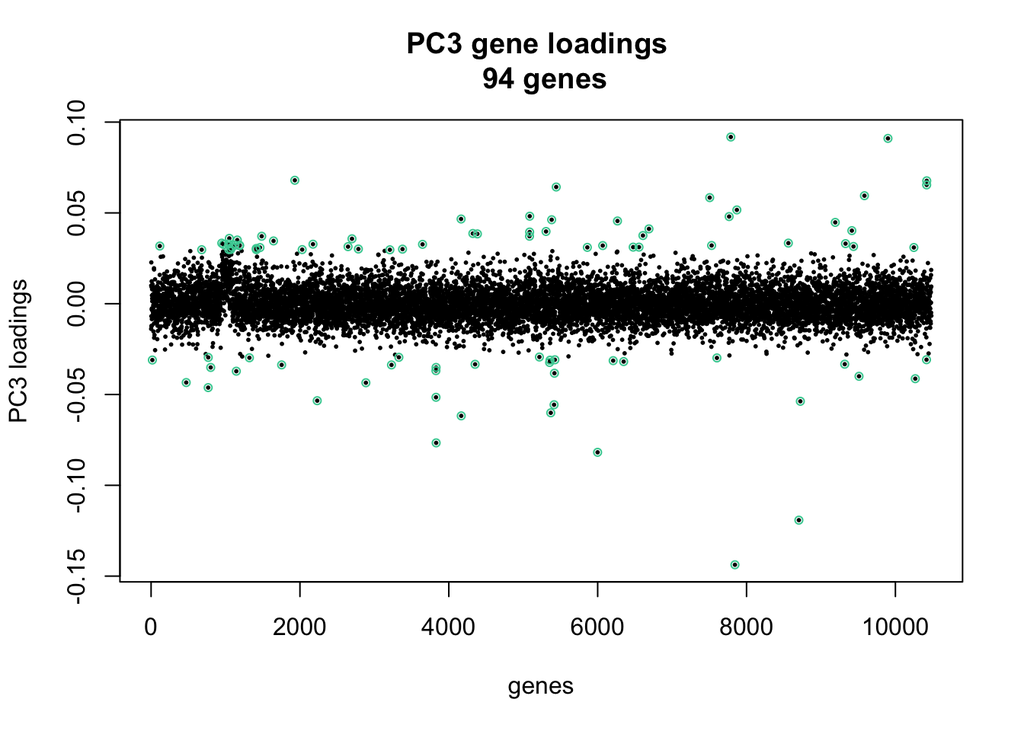

[figure not shown]

Annotation

```r
library("biomaRt")
ensembl <- useMart(host = "grch37.ensembl.org",
                   biomart = "ENSEMBL_MART_ENSEMBL",
                   dataset = "hsapiens_gene_ensembl")
pc3_gene_info <- getBM(attributes = c("ensembl_gene_id", "chromosome_name",
                                       "external_gene_name", "transcript_count",
                                       "description"),
                        filters = "ensembl_gene_id",
                        values = rownames(molecules_ENSG[ii_extreme, ]),
                        mart = ensembl)
kable(pc3_gene_info[ , c(1, 2, 3, 5)])
```

| ensembl_gene_id | chromosome_name | external_gene_name | description |
| --- | --- | --- | --- |
| ENSG00000003436 | 2 | TFPI | tissue factor pathway inhibitor (lipoprotein-associated coagulation inhibitor) [Source:HGNC Symbol;Acc:11760] |
| ENSG00000004700 | 12 | RECQL | RecQ protein-like (DNA helicase Q1-like) [Source:HGNC Symbol;Acc:9948] |
| ENSG00000022556 | 19 | NLRP2 | NLR family, pyrin domain containing 2 [Source:HGNC Symbol;Acc:22948] |
| ENSG00000026025 | 10 | VIM | vimentin [Source:HGNC Symbol;Acc:12692] |
| ENSG00000054282 | 1 | SDCCAG8 | serologically defined colon cancer antigen 8 [Source:HGNC Symbol;Acc:10671] |
| ENSG00000063241 | 19 | ISOC2 | isochorismatase domain containing 2 [Source:HGNC Symbol;Acc:26278] |
| ENSG00000064042 | 4 | LIMCH1 | LIM and calponin homology domains 1 [Source:HGNC Symbol;Acc:29191] |
| ENSG00000065621 | 10 | GSTO2 | glutathione S-transferase omega 2 [Source:HGNC Symbol;Acc:23064] |
| ENSG00000075407 | 10 | ZNF37A | zinc finger protein 37A [Source:HGNC Symbol;Acc:13102] |
| ENSG00000078018 | 2 | MAP2 | microtubule-associated protein 2 [Source:HGNC Symbol;Acc:6839] |
| ENSG00000091947 | 17 | TMEM101 | transmembrane protein 101 [Source:HGNC Symbol;Acc:28653] |
| ENSG00000100097 | 22 | LGALS1 | lectin, galactoside-binding, soluble, 1 [Source:HGNC Symbol;Acc:6561] |
| ENSG00000100918 | 14 | REC8 | REC8 meiotic recombination protein [Source:HGNC Symbol;Acc:16879] |
| ENSG00000101098 | 20 | RIMS4 | regulating synaptic membrane exocytosis 4 [Source:HGNC Symbol;Acc:16183] |
| ENSG00000101224 | 20 | CDC25B | cell division cycle 25B [Source:HGNC Symbol;Acc:1726] |
| ENSG00000102309 | X | PIN4 | protein (peptidylprolyl cis/trans isomerase) NIMA-interacting, 4 (parvulin) [Source:HGNC Symbol;Acc:8992] |
| ENSG00000104723 | 8 | TUSC3 | tumor suppressor candidate 3 [Source:HGNC Symbol;Acc:30242] |
| ENSG00000105357 | 19 | MYH14 | myosin, heavy chain 14, non-muscle [Source:HGNC Symbol;Acc:23212] |
| ENSG00000105499 | 19 | PLA2G4C | phospholipase A2, group IVC (cytosolic, calcium-independent) [Source:HGNC Symbol;Acc:9037] |
| ENSG00000118523 | 6 | CTGF | connective tissue growth factor [Source:HGNC Symbol;Acc:2500] |
| ENSG00000125144 | 16 | MT1G | metallothionein 1G [Source:HGNC Symbol;Acc:7399] |
| ENSG00000128052 | 4 | KDR | kinase insert domain receptor (a type III receptor tyrosine kinase) [Source:HGNC Symbol;Acc:6307] |
| ENSG00000128610 | 7 | FEZF1 | FEZ family zinc finger 1 [Source:HGNC Symbol;Acc:22788] |
| ENSG00000129991 | 19 | TNNI3 | troponin I type 3 (cardiac) [Source:HGNC Symbol;Acc:11947] |
| ENSG00000131203 | 8 | IDO1 | indoleamine 2,3-dioxygenase 1 [Source:HGNC Symbol;Acc:6059] |
| ENSG00000132950 | 13 | ZMYM5 | zinc finger, MYM-type 5 [Source:HGNC Symbol;Acc:13029] |
| ENSG00000133107 | 13 | TRPC4 | transient receptor potential cation channel, subfamily C, member 4 [Source:HGNC Symbol;Acc:12336] |
| ENSG00000134595 | X | SOX3 | SRY (sex determining region Y)-box 3 [Source:HGNC Symbol;Acc:11199] |
| ENSG00000134874 | 13 | DZIP1 | DAZ interacting zinc finger protein 1 [Source:HGNC Symbol;Acc:20908] |
| ENSG00000135549 | 6 | PKIB | protein kinase (cAMP-dependent, catalytic) inhibitor beta [Source:HGNC Symbol;Acc:9018] |

[output cut: 64 more lines]

```r
if (file.exists("rda/svd-filtered/pc3-cv.rda")) {
  load("rda/svd-filtered/pc3-cv.rda")
} else {
  library(Humanzee)
  go_pc3 <- GOtest(my_ensembl_gene_universe = rownames(molecules_ENSG),
                my_ensembl_gene_test = rownames(molecules_ENSG)[ii_extreme],
                pval_cutoff = 1, ontology=c("BP","CC","MF") )
  save(go_pc3, file = "rda/svd-filtered/pc2-cv.rda")
}
```

Extract terms

```r
if (file.exists("rda/svd-filtered/go-pc3-terms.rda")) {
  load("rda/svd-filtered/go-pc3-terms.rda")
} else {
  # Biological process
  goterms_bp <- summary(go_pc3$GO$BP, pvalue = 1)
  goterms_bp <- data.frame(ID = goterms_bp[[1]],
                           Pvalue = goterms_bp[[2]],
                           Terms = goterms_bp[[7]])
  goterms_bp <- goterms_bp[order(goterms_bp$Pvalue), ]

  # Cellular component
  goterms_cc <- summary(go_pc3$GO$CC, pvalue = 1)
  goterms_cc <- data.frame(ID = goterms_cc[[1]],
                           Pvalue = goterms_cc[[2]],
                           Terms = goterms_cc[[7]])
  goterms_cc <- goterms_cc[order(goterms_cc$Pvalue), ]

  # Molecular function
  goterms_mf <- summary(go_pc3$GO$MF, pvalue = 1)
  goterms_mf <- data.frame(ID = goterms_mf[[1]],
                           Pvalue = goterms_mf[[2]],
                           Terms = goterms_mf[[7]])
  goterms_mf <- goterms_mf[order(goterms_mf$Pvalue), ]

  save(goterms_bp, goterms_cc, goterms_mf,
       file = "rda/svd-filtered/go-pc3-terms.rda")
}
```

```r
head(goterms_bp, 20)
```

```
           ID       Pvalue
1  GO:0071294 3.878761e-07
2  GO:0071276 1.148025e-06
3  GO:0071241 1.117054e-05
4  GO:0010043 1.994167e-05
5  GO:0071248 7.431671e-05
6  GO:0046686 9.915044e-05
7  GO:1901685 4.151958e-04
8  GO:1901687 4.151958e-04
9  GO:0031589 4.247346e-04
10 GO:0036149 7.602917e-04
11 GO:0006936 9.161115e-04
12 GO:0002544 1.133887e-03
13 GO:0045989 1.133887e-03
14 GO:1990267 1.286417e-03
```

[output cut: 27 more lines]

```r
head(goterms_cc, 20)
```

```
           ID      Pvalue                              Terms
1  GO:0005589 0.008785692            collagen type VI trimer
2  GO:0030485 0.008785692    smooth muscle contractile fiber
3  GO:0044228 0.008785692                  host cell surface
4  GO:0098647 0.008785692           collagen beaded filament
5  GO:0031012 0.010730464               extracellular matrix
6  GO:0005577 0.017495106                 fibrinogen complex
7  GO:0097443 0.017495106                   sorting endosome
8  GO:0005578 0.021674083 proteinaceous extracellular matrix
9  GO:0048471 0.022341863    perinuclear region of cytoplasm
10 GO:0000798 0.026128898            nuclear cohesin complex
11 GO:0034991 0.026128898    nuclear meiotic cohesin complex
12 GO:0097513 0.026128898                 myosin II filament
13 GO:0005882 0.031905152              intermediate filament
14 GO:0018995 0.034687715                               host
15 GO:0030893 0.034687715            meiotic cohesin complex
16 GO:0032982 0.034687715                    myosin filament
17 GO:0033643 0.034687715                     host cell part
18 GO:0043245 0.034687715              extraorganismal space
19 GO:0043657 0.034687715                          host cell
20 GO:0044215 0.034687715                     other organism
```

```r
head(goterms_mf, 20)
```

```
           ID       Pvalue
1  GO:0016672 7.222821e-05
2  GO:0045174 7.222821e-05
3  GO:0050610 7.222821e-05
4  GO:0004364 1.619106e-04
5  GO:0019838 1.920784e-04
6  GO:0030613 2.154802e-04
7  GO:0030614 2.154802e-04
8  GO:0016765 4.334233e-04
9  GO:0015038 7.103117e-04
10 GO:0001948 7.841233e-04
11 GO:0015037 1.059556e-03
12 GO:0050840 1.358660e-03
13 GO:0005178 1.680954e-03
14 GO:0050839 1.913923e-03
```

[output cut: 27 more lines]